# Br.microbiom.exp3.v3.0.annotationDEG.2018v1

Kazu

9/25/2018

# purpose: Raw count files to DEGs

# History

- For reorganization, create this script from scratch. (092518)
- Adding MDS plot with block info (090619)

```r
knitr::opts_chunk$set(echo = TRUE,error=TRUE)
```

```r
library(edgeR);library(tidyverse);library(readr);library(readxl)
```

# For Mapping reads with Kalisoga see “Map and normalize.Rmd” in “./v3.0annotation/20170617-samples/scripts”

# load reads mapped to v3.0 Brassica genome

```r
getwd()
```

```
## [1] "/Volumes/data_work/Data8/NGS_related/Brassica_microbiome/Brapa_microbes_rebuilt1/v3.0annotation/20180202-samples/scripts"
```

```r
counts <- readr::read_csv(file.path("..","input","20180202_V3.0_raw_counts.csv.gz"))
counts # make sure this is v3.0 annotation (look target_id column)
```

```
## # A tibble: 46,250 x 65
##    target_id a1_5e_live_cr_3… a2_5e_dead_cr_3… a3_5e_dead_un_3…
##    <chr>                <dbl>            <dbl>            <dbl>
##  1 BraA01g0…             6                3                5.54
##  2 BraA01g0…           103.              80.5             51.9
##  3 BraA01g0…             2.06             2.02             1.01
##  4 BraA01g0…           212.             213.             339.
##  5 BraA01g0…            11               15               27
##  6 BraA01g0…             0                0                0
##  7 BraA01g0…            11               26               36
##  8 BraA01g0…            68               96               97
##  9 BraA01g0…           119.             100.             205.
## 10 BraA01g0…             7.57            45.4              7.57
## # … with 46,240 more rows, and 61 more variables:
## #   a4_5e_dead_un_3_a47_S4 <dbl>, a5_5e_dead_cr_3_a54_S5 <dbl>,
## #   a6_5e_live_cr_3_a56_S6 <dbl>, a7_5e_live_un_3_a57_S7 <dbl>,
## #   a8_5e_live_un_3_a60_S8 <dbl>, b1_5e_live_cr_3_a42_S9 <dbl>,
## #   b2_5e_dead_cr_3_a44_S10 <dbl>, b3_5e_dead_un_3_a46_S11 <dbl>,
## #   b4_5e_dead_un_3_a47_S12 <dbl>, b5_5e_dead_cr_3_a54_S13 <dbl>,
## #   b6_5e_live_cr_3_a56_S14 <dbl>, b7_5e_live_un_3_a57_S15 <dbl>,
## #   b8_5e_live_un_3_a60_S16 <dbl>, c1_5e_live_un_6_a103_S17 <dbl>,
## #   c2_5e_dead_cr_6_a104_S18 <dbl>, c3_5e_live_cr_6_a109_S19 <dbl>,
## #   c4_5e_dead_un_6_a112_S20 <dbl>, c5_5e_live_un_6_a114_S21 <dbl>,
## #   c6_5e_dead_un_6_a117_S22 <dbl>, c7_5e_dead_cr_6_a119_S23 <dbl>,
## #   c8_5e_live_cr_6_a120_S24 <dbl>, d1_5e_live_un_6_a103_S25 <dbl>,
## #   d2_5e_dead_cr_6_a104_S26 <dbl>, d3_5e_live_cr_6_a109_S27 <dbl>,
## #   d4_5e_dead_un_6_a112_S28 <dbl>, d5_5e_live_un_6_a114_S29 <dbl>,
## #   d6_5e_dead_un_6_a117_S30 <dbl>, d7_5e_dead_cr_6_a119_S31 <dbl>,
## #   d8_5e_live_cr_6_a120_S32 <dbl>, e1_5e_dead_cr_8_a142_S33 <dbl>,
## #   e2_5e_live_un_8_a146_S34 <dbl>, e3_5e_live_un_8_a150_S35 <dbl>,
## #   e4_5e_live_cr_8_a151_S36 <dbl>, e5_5e_dead_un_8_a152_S37 <dbl>,
## #   e6_5e_dead_cr_8_a153_S38 <dbl>, e7_5e_live_cr_8_a157_S39 <dbl>,
## #   e8_5e_dead_un_8_a159_S40 <dbl>, f1_5e_dead_cr_8_a142_S41 <dbl>,
## #   f2_5e_live_un_8_a146_S42 <dbl>, f3_5e_live_un_8_a150_S43 <dbl>,
## #   f4_5e_live_cr_8_a151_S44 <dbl>, f5_5e_dead_un_8_a152_S45 <dbl>,
## #   f6_5e_dead_cr_8_a153_S46 <dbl>, f7_5e_live_cr_8_a157_S47 <dbl>,
## #   f8_5e_dead_un_8_a159_S48 <dbl>, g1_5e_dead_un_12_a223_S49 <dbl>,
## #   g2_5e_dead_un_12_a226_S50 <dbl>, g3_5e_dead_cr_12_a228_S51 <dbl>,
## #   g4_5e_live_un_12_a229_S52 <dbl>, g5_5e_live_un_12_a230_S53 <dbl>,
## #   g6_5e_dead_cr_12_a235_S54 <dbl>, g7_5e_live_cr_12_a236_S55 <dbl>,
## #   g8_5e_live_cr_12_a240_S56 <dbl>, h1_5e_dead_un_12_a223_S57 <dbl>,
## #   h2_5e_dead_un_12_a226_S58 <dbl>, h3_5e_dead_cr_12_a228_S59 <dbl>,
## #   h4_5e_live_un_12_a229_S60 <dbl>, h5_5e_live_un_12_a230_S61 <dbl>,
## #   h6_5e_dead_cr_12_a235_S62 <dbl>, h7_5e_live_cr_12_a236_S63 <dbl>,
## #   h8_5e_live_cr_12_a240_S64 <dbl>
```

## make sample description data frame (modified from Juiln’s script “Map and normalize.Rmd”

```r
# separate() is useful (like split() in Base package. See "R for data science" pg157)
sample.description <- tibble(sample=colnames(counts)[-1]) %>%
  separate(sample,
           c("location","soil","trt","density","block","pot","unknown2"),
           remove=FALSE,
           convert=FALSE) %>% unite(sample2,c("location","soil","trt","density","block","pot"),remove=FALSE)
head(sample.description)
```

```
## # A tibble: 6 x 9
##   sample       sample2    location soil  trt   density block pot   unknown2
##   <chr>        <chr>      <chr>    <chr> <chr> <chr>   <chr> <chr> <chr>
## 1 a1_5e_live_… a1_5e_liv… a1       5e    live  cr      3     a42   S1
## 2 a2_5e_dead_… a2_5e_dea… a2       5e    dead  cr      3     a44   S2
## 3 a3_5e_dead_… a3_5e_dea… a3       5e    dead  un      3     a46   S3
## 4 a4_5e_dead_… a4_5e_dea… a4       5e    dead  un      3     a47   S4
## 5 a5_5e_dead_… a5_5e_dea… a5       5e    dead  cr      3     a54   S5
## 6 a6_5e_live_… a6_5e_liv… a6       5e    live  cr      3     a56   S6
```

```r
#type_convert(sample.description[,-3]) # to keep "unknown" column as character type.
#sample.description$block<-as.integer(sample.description$block)
# change lowercases into uppercases in soil column and character into integer in block
sample.description<-sample.description %>% mutate(soil=toupper(soil)) %>% mutate(block=str_c("b", as.integer(block))) ## get additional metadata. (Oct 14, 2019) Block effects have to be character, not integer!!!!

sample.info <- read_tsv(file.path("..","input","20180202-data","wy003-metadata.txt"), col_names=c("sample2","tissue","soil","trt","density","block","pot"),skip=1) # do I need to add thi info? Yes for tissue info.
head(sample.info)
```

```
## # A tibble: 6 x 7
##   sample2             tissue  soil trt   density block pot
##   <chr>               <chr>  <dbl> <chr> <chr>   <dbl> <chr>
## 1 a1_5e_live_cr_3_a42 root       5 live  CR          3 A42
## 2 a2_5e_dead_cr_3_a44 root       5 dead  CR          3 A44
## 3 a3_5e_dead_un_3_a46 root       5 dead  UN          3 A46
## 4 a4_5e_dead_un_3_a47 root       5 dead  UN          3 A47
## 5 a5_5e_dead_cr_3_a54 root       5 dead  CR          3 A54
## 6 a6_5e_live_cr_3_a56 root       5 live  CR          3 A56
```

```r
#sample.info %>% mutate(block=as.integer(block))
##combine
sample.description2 <- left_join(sample.description, dplyr::select(sample.info,c(sample2,tissue))) %>% dplyr::select(-sample2) #
sample.description2 <- sample.description2 %>%
  mutate(group=paste(trt,density,tissue,sep="_"))
head(sample.description2)
```

```
## # A tibble: 6 x 10
##   sample    location soil  trt   density block pot   unknown2 tissue group
##   <chr>     <chr>    <chr> <chr> <chr>   <chr> <chr> <chr>    <chr>  <chr>
## 1 a1_5e_li… a1       5E    live  cr      b3    a42   S1       root   live_…
## 2 a2_5e_de… a2       5E    dead  cr      b3    a44   S2       root   dead_…
## 3 a3_5e_de… a3       5E    dead  un      b3    a46   S3       root   dead_…
## 4 a4_5e_de… a4       5E    dead  un      b3    a47   S4       root   dead_…
## 5 a5_5e_de… a5       5E    dead  cr      b3    a54   S5       root   dead_…
## 6 a6_5e_li… a6       5E    live  cr      b3    a56   S6       root   live_…
```

```r
sample.description2 %>% summarize(n_distinct(group)) # n_distinct()
```

```
## # A tibble: 1 x 1
##   `n_distinct(group)`
##                 <int>
## 1                   8
```

```r
write_csv(sample.description2,path=file.path("..","output","Br.mbio.e3.sample.description.csv")) # change file name
# data.frame version
sample.description2.DF<-data.frame(sample.description2)
```

## summarize counts

## load to edgeR, normalize

Looks like we should normalize separately for root and leaf # do separately for leaf and root values

# Leaf

# Root

# save edgeR objects

# leaf MDS plot bcv

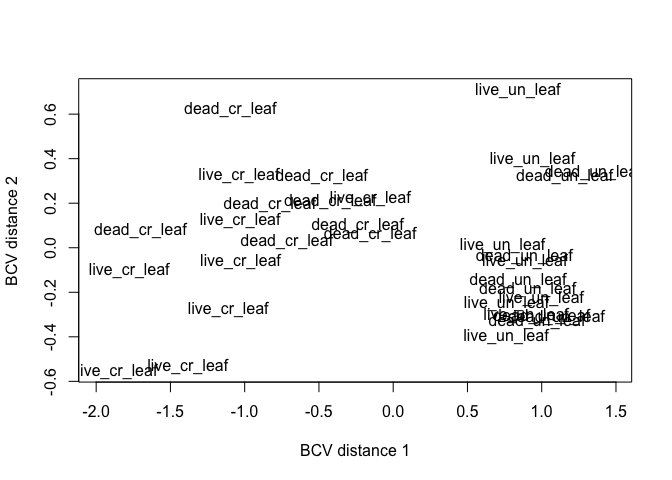

```r
load(file.path("..","output","edgeR_dge_objects.e3.v3.0anno.RData"))
# leaf
mds.leaf <- plotMDS(dge.leaf,method = "bcv",labels=dge.leaf$samples$group,gene.selection = "pairwise",dim.plot = c(1,2),ndim=5)
```

```r
mds.leaf.pl <- as_tibble(mds.leaf$cmdscale.out) %>%
  bind_cols(data.frame(sample=row.names(mds.leaf$cmdscale.out)),.) %>%
  inner_join(dge.leaf$samples)
```

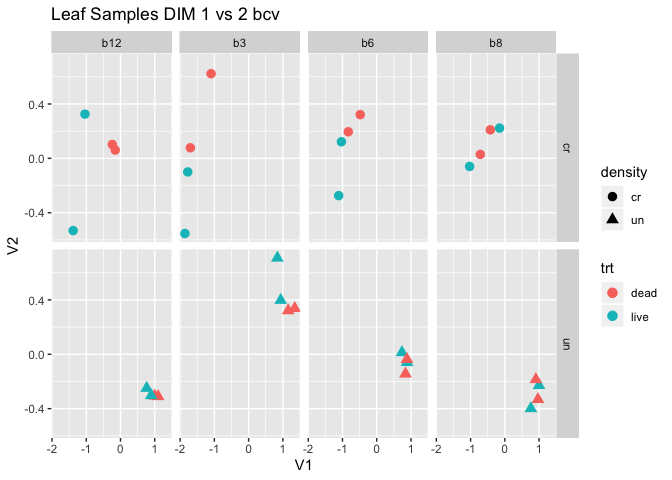

```r
# V1 vs V2
p.V1.V2<-mds.leaf.pl %>% ggplot(aes(x=V1,y=V2, shape=density, color=trt,label=density)) + geom_point(size=3) + ggtitle("Leaf Samples DIM 1 vs 2 bcv")+ facet_grid(density~block) + theme_gray()
p.V1.V2
```

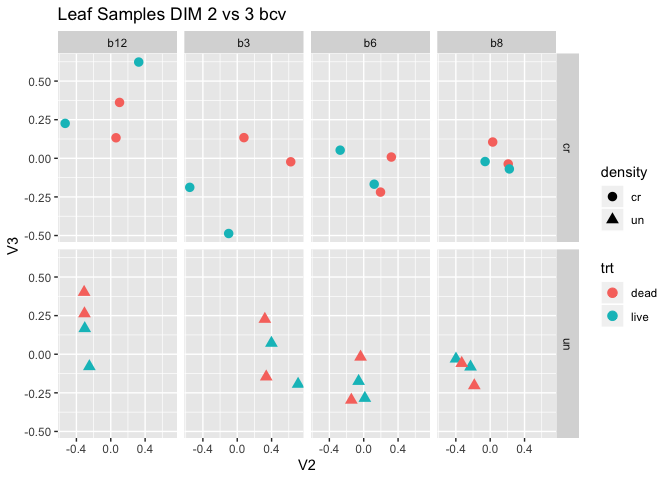

```r
ggsave(filename="../output/e3.leaf.mds.bcv.1and2.png",width=6,height=8)
# V2 vs V3
p.V2.V3<-mds.leaf.pl %>% ggplot(aes(x=V2,y=V3, shape=density, color=trt,label=density)) + geom_point(size=3) + ggtitle("Leaf Samples DIM 2 vs 3 bcv")+ facet_grid(density~block)+ theme_gray()
p.V2.V3
```

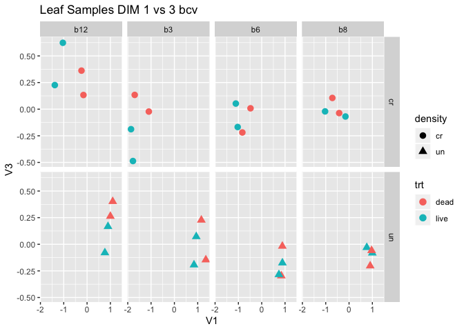

```r
ggsave(filename="../output/e3.leaf.mds.bcv.2and3.png",width=6,height=8)
# V1 vs V3
p.V1.V3<-mds.leaf.pl %>% ggplot(aes(x=V1,y=V3, shape=density, color=trt,label=density)) + geom_point(size=3) + ggtitle("Leaf Samples DIM 1 vs 3 bcv")+ facet_grid(density~block)+ theme_gray()
p.V1.V3
```

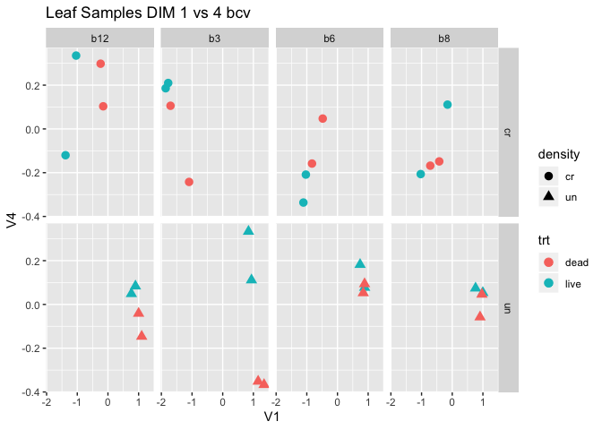

```r
ggsave(filename="../output/e3.leaf.mds.bcv.1and3.png",width=6,height=8)
# V1 vs V4
p.V1.V4<-mds.leaf.pl %>% ggplot(aes(x=V1,y=V4, shape=density, color=trt,label=density)) + geom_point(size=3) + ggtitle("Leaf Samples DIM 1 vs 4 bcv")+ facet_grid(density~block)+ theme_gray()
p.V1.V4
```

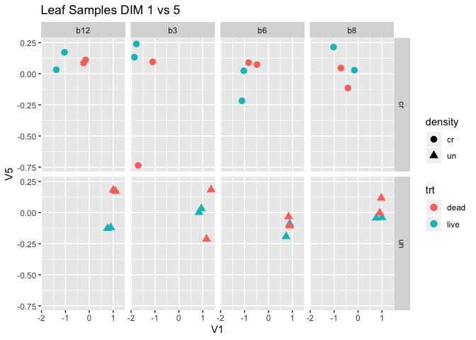

```r
ggsave(filename="../output/e3.leaf.mds.bcv.1and4.png",width=6,height=8)
# V1 vs V5
p.V1.V5<-mds.leaf.pl %>% ggplot(aes(x=V1,y=V5, shape=density, color=trt,label=density)) + geom_point(size=3) + ggtitle("Leaf Samples DIM 1 vs 5")+ facet_grid(density~block)+ theme_gray()
p.V1.V5
```

```r
ggsave(filename="../output/e3.leaf.mds.bcv.1and5.png",width=6,height=8)
```

# leaf MDS logFC

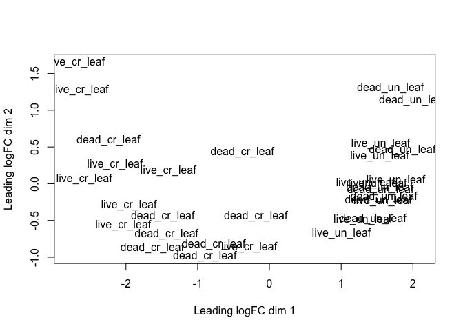

```r
mds.leaf.logFC <- plotMDS(dge.leaf,method = "logFC",labels=dge.leaf$samples$group,gene.selection = "pairwise",dim.plot = c(1,2),ndim=5) # changed ndim=3 into 5
```

```r
mds.leaf.pl.logFC <- as_tibble(mds.leaf.logFC$cmdscale.out) %>%
  bind_cols(data.frame(sample=row.names(mds.leaf.logFC$cmdscale.out)),.) %>%
  inner_join(dge.leaf$samples)
```

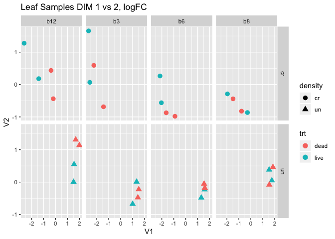

```r
# adding block info
# V1 vs V2
p.V1.V2.logFC<-mds.leaf.pl.logFC %>% ggplot(aes(x=V1,y=V2, shape=density, color=trt,label=density)) + geom_point(size=3) + ggtitle("Leaf Samples DIM 1 vs 2, logFC") + facet_grid(density~block)+ theme_gray()
p.V1.V2.logFC
```

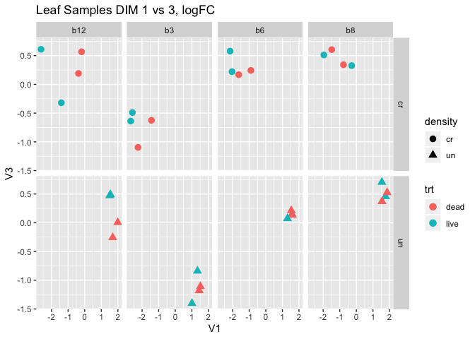

```r
ggsave(filename="../output/e3.leaf.mds.logFC.1and2.png",width=6,height=8)
# V1 vs V3
p.V1.V3.logFC<-mds.leaf.pl.logFC %>% ggplot(aes(x=V1,y=V3, shape=density, color=trt,label=density)) + geom_point(size=3) + ggtitle("Leaf Samples DIM 1 vs 3, logFC")+ facet_grid(density~block)+ theme_gray()
p.V1.V3.logFC
```

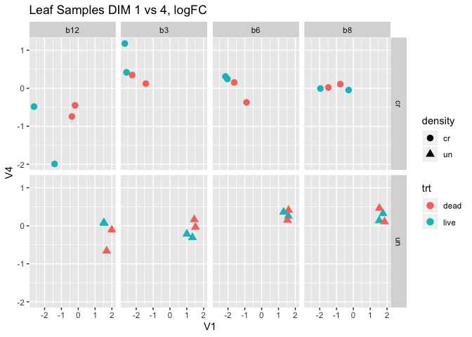

```r
ggsave(filename="../output/e3.leaf.mds.logFC.1and3.png",width=6,height=8)
# V1 vs V4
p.V1.V4.logFC<-mds.leaf.pl.logFC %>% ggplot(aes(x=V1,y=V4, shape=density, color=trt,label=density)) + geom_point(size=3) + ggtitle("Leaf Samples DIM 1 vs 4, logFC")+ facet_grid(density~block)+ theme_gray()
p.V1.V4.logFC
```

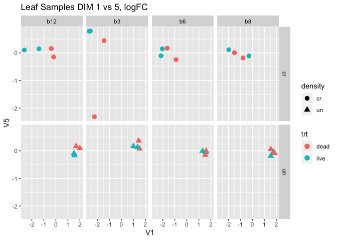

```r
ggsave(filename="../output/e3.leaf.mds.logFC.1and4.png",width=6,height=8)
# V1 vs V5
p.V1.V5.logFC<-mds.leaf.pl.logFC %>% ggplot(aes(x=V1,y=V5, shape=density, color=trt,label=density)) + geom_point(size=3) + ggtitle("Leaf Samples DIM 1 vs 5, logFC")+ facet_grid(density~block)+ theme_gray()
p.V1.V5.logFC
```

```r
ggsave(filename="../output/e3.leaf.mds.logFC.1and5.png",width=6,height=8)
```

# root MDS plot bcv

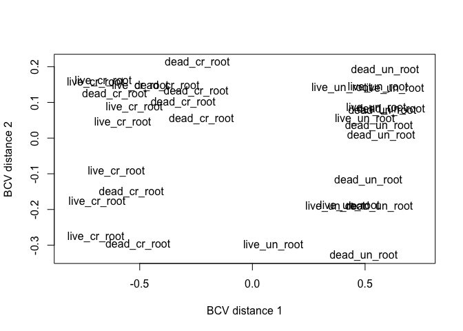

```r
# root
mds.root <- plotMDS(dge.root,method = "bcv",labels=dge.root$samples$group,gene.selection = "pairwise",dim.plot = c(1,2),ndim=5)
```

```r
mds.root.pl <- as_tibble(mds.root$cmdscale.out) %>%
  bind_cols(data.frame(sample=row.names(mds.root$cmdscale.out)),.) %>%
  inner_join(dge.root$samples)
```

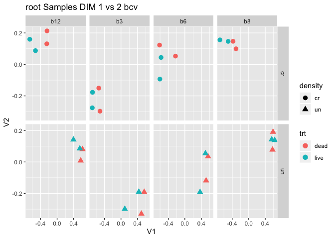

```r
# V1 vs V2
p.V1.V2<-mds.root.pl %>% ggplot(aes(x=V1,y=V2, shape=density, color=trt,label=density)) + geom_point(size=3) + ggtitle("root Samples DIM 1 vs 2 bcv")+ facet_grid(density~block)+ theme_gray()
p.V1.V2
```

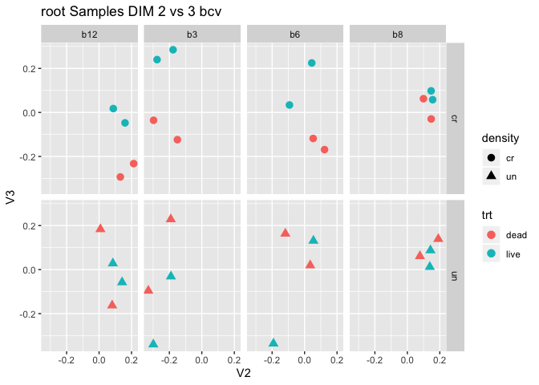

```r
ggsave(filename="../output/e3.root.mds.bcv.1and2.png",width=6,height=8)
# V2 vs V3
p.V2.V3<-mds.root.pl %>% ggplot(aes(x=V2,y=V3, shape=density, color=trt,label=density)) + geom_point(size=3) + ggtitle("root Samples DIM 2 vs 3 bcv")+ facet_grid(density~block)+ theme_gray()
p.V2.V3
```

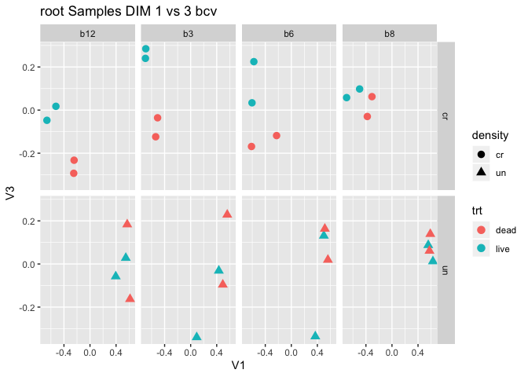

```r
ggsave(filename="../output/e3.root.mds.bcv.2and3.png",width=6,height=8)
# V1 vs V3
p.V1.V3<-mds.root.pl %>% ggplot(aes(x=V1,y=V3, shape=density, color=trt,label=density)) + geom_point(size=3) + ggtitle("root Samples DIM 1 vs 3 bcv")+ facet_grid(density~block)+ theme_gray()
p.V1.V3
```

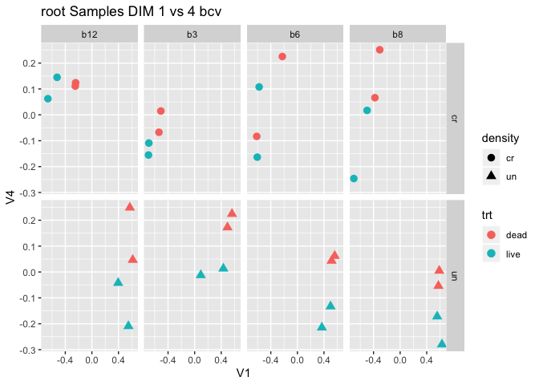

```r
ggsave(filename="../output/e3.root.mds.bcv.1and3.png",width=6,height=8)
# V1 vs V4
p.V1.V4<-mds.root.pl %>% ggplot(aes(x=V1,y=V4, shape=density, color=trt,label=density)) + geom_point(size=3) + ggtitle("root Samples DIM 1 vs 4 bcv")+ facet_grid(density~block)+ theme_gray()
p.V1.V4
```

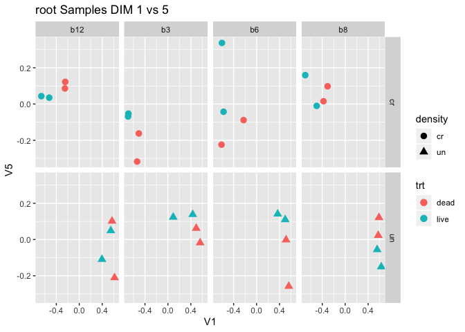

```r
ggsave(filename="../output/e3.root.mds.bcv.1and4.png",width=6,height=8)
# V1 vs V5
p.V1.V5<-mds.root.pl %>% ggplot(aes(x=V1,y=V5, shape=density, color=trt,label=density)) + geom_point(size=3) + ggtitle("root Samples DIM 1 vs 5")+ facet_grid(density~block)+ theme_gray()
p.V1.V5
```

```r
ggsave(filename="../output/e3.root.mds.bcv.1and5.png",width=6,height=8)
```

# root MDS logFC

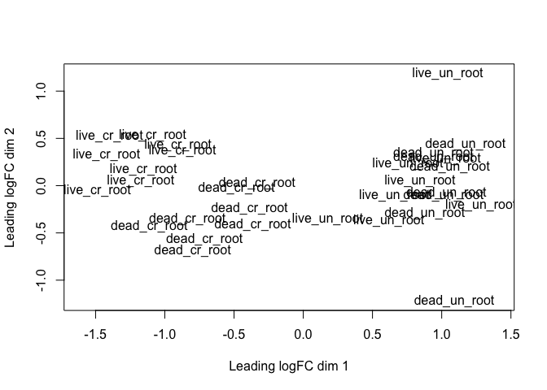

```r
mds.root.logFC <- plotMDS(dge.root,method = "logFC",labels=dge.root$samples$group,gene.selection = "pairwise",dim.plot = c(1,2),ndim=5) # changed ndim=3 into 5
```

```r
mds.root.pl.logFC <- as_tibble(mds.root.logFC$cmdscale.out) %>%
  bind_cols(data.frame(sample=row.names(mds.root.logFC$cmdscale.out)),.) %>%
  inner_join(dge.root$samples)
```

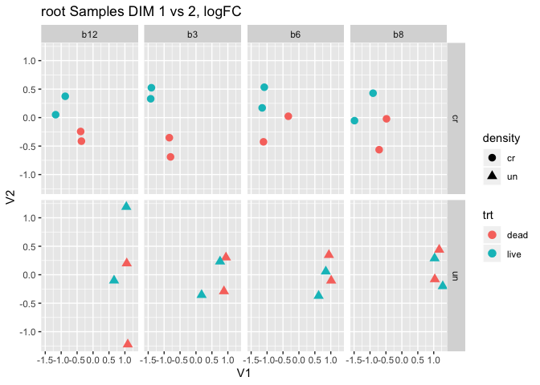

```r
# adding block info
# V1 vs V2
p.V1.V2.logFC<-mds.root.pl.logFC %>% ggplot(aes(x=V1,y=V2, shape=density, color=trt,label=density)) + geom_point(size=3) + ggtitle("root Samples DIM 1 vs 2, logFC") + facet_grid(density~block)+ theme_gray()
p.V1.V2.logFC
```

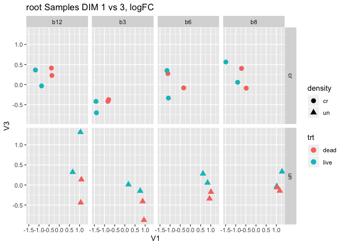

```r
ggsave(filename="../output/e3.root.mds.logFC.1and2.png",width=6,height=8)
# V1 vs V3
p.V1.V3.logFC<-mds.root.pl.logFC %>% ggplot(aes(x=V1,y=V3, shape=density, color=trt,label=density)) + geom_point(size=3) + ggtitle("root Samples DIM 1 vs 3, logFC")+ facet_grid(density~block)+ theme_gray()
p.V1.V3.logFC
```

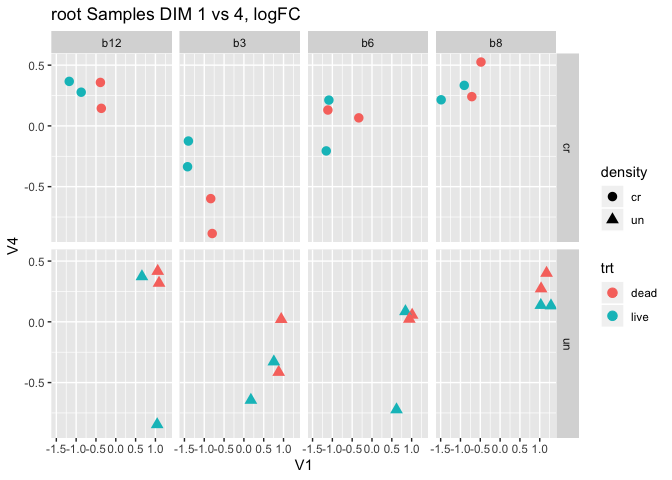

```r
ggsave(filename="../output/e3.root.mds.logFC.1and3.png",width=6,height=8)
# V1 vs V4
p.V1.V4.logFC<-mds.root.pl.logFC %>% ggplot(aes(x=V1,y=V4, shape=density, color=trt,label=density)) + geom_point(size=3) + ggtitle("root Samples DIM 1 vs 4, logFC")+ facet_grid(density~block)+ theme_gray()
p.V1.V4.logFC
```

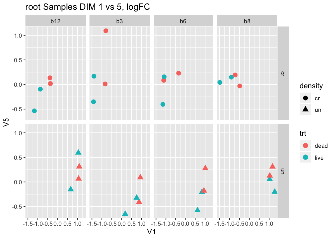

```r
ggsave(filename="../output/e3.root.mds.logFC.1and4.png",width=6,height=8)
# V1 vs V5
p.V1.V5.logFC<-mds.root.pl.logFC %>% ggplot(aes(x=V1,y=V5, shape=density, color=trt,label=density)) + geom_point(size=3) + ggtitle("root Samples DIM 1 vs 5, logFC")+ facet_grid(density~block)+ theme_gray()
p.V1.V5.logFC
```

```r
ggsave(filename="../output/e3.root.mds.logFC.1and5.png",width=6,height=8)
```

# DEGs prep

```r
# clean working directory
rm(list=ls())
knitr::opts_chunk$set(echo = TRUE,error=TRUE)
library(edgeR);library(tidyverse)
# annotation file for v3.0annotation
Br.v3.0.At.BLAST <- read_csv(file.path("..","..","..","Annotation","output","v3.0annotation","Brapa_v3.0_annotated.csv"))
# This annotation is redundant with name (Br grene). Eg
Br.v3.0.At.BLAST %>% filter(name=="BraA01g040570.3C")
```

```
## # A tibble: 2 x 23
##      X1 name  chrom  start    end subject AGI   At_symbol At_full_name
##   <dbl> <chr> <chr>  <dbl>  <dbl> <chr>   <chr> <chr>     <chr>
## 1  3848 BraA… A01   2.73e7 2.73e7 AT3G09… AT3G… AIRP3     ABA insensi…
## 2  3849 BraA… A01   2.73e7 2.73e7 AT5G03… AT5G… LUL1      LOG2-LIKE U…
## # … with 14 more variables: At_gene_model_type <chr>,
## #   At_short_description <chr>, At_Curator_summary <chr>,
## #   At_Computational_description <chr>, perc_ID <dbl>, aln_length <dbl>,
## #   mismatch <dbl>, gap_open <dbl>, qstart <dbl>, qend <dbl>,
## #   sstart <dbl>, send <dbl>, eval <dbl>, score <dbl>
```

```r
# reduce the redundancy (112418)
Br.v3.0anno.At.BLAST.highscore <- Br.v3.0.At.BLAST %>% group_by(name) %>% arrange(desc(score)) %>% slice(1)

# load exp1 v3.0 annotation dge files and sample info
load(file.path("..","output","edgeR_dge_objects.e3.v3.0anno.RData"))
# for expression pattern graph
source("../../../tools/Expression_pattern_graph.R",chdir=TRUE)
# "/Volumes/data_work/Data8/NGS_related/Brassica_microbiome/Brapa_microbes/tools"
```

# Additive model, rD.rUN

```r
# relevel trt and density to "dead" and "uncrowd"
dge.root$samples<-dge.root$samples %>% mutate(trt=fct_relevel(trt,"dead")) # %>% str()
dge.root$samples<-dge.root$samples %>% mutate(density=fct_relevel(density,"un")) #%>% str()
dge.leaf$samples<-dge.leaf$samples %>% mutate(trt=fct_relevel(trt,"dead")) #%>% str()
dge.leaf$samples<-dge.leaf$samples %>% mutate(density=fct_relevel(density,"un")) #%>% str()
## dge
root.design.add <- with(dge.root$samples, model.matrix(~ density + trt + block))
leaf.design.add <- with(dge.leaf$samples, model.matrix(~ density + trt + block))
# estimateDisp
root.dge.add <- estimateDisp(dge.root,design = root.design.add)
leaf.dge.add <- estimateDisp(dge.leaf,design = leaf.design.add)
## fit linear model
root.fit.add <- glmFit(root.dge.add,root.design.add)
leaf.fit.add <- glmFit(leaf.dge.add,leaf.design.add)
# get DEGs, trt effects (coef=c("trtlive"))
root.trtlive.lrt <- glmLRT(root.fit.add,coef = c("trtlive"))
leaf.trtlive.lrt <- glmLRT(leaf.fit.add,coef = c("trtlive"))
topTags(root.trtlive.lrt);topTags(leaf.trtlive.lrt)
```

```
## Coefficient:  trtlive
##                  genes      logFC   logCPM       LR       PValue
## 20374 BraA05g014790.3C -2.2106804 1.587361 66.27469 3.922626e-16
## 18062 BraA04g024250.3C  0.5883919 8.540887 60.19340 8.598023e-15
## 17236 BraA04g015990.3C  1.8096834 1.761986 48.65912 3.045486e-12
## 39595 BraA09g040290.3C  0.5058879 7.514521 48.38059 3.510263e-12
## 34734 BraA08g027460.3C  1.6172327 1.606219 47.71166 4.937469e-12
## 37267 BraA09g017010.3C -1.0998524 2.652267 47.69420 4.981629e-12
## 10652 BraA03g015680.3C  0.5788164 6.150705 46.76210 8.014863e-12
## 24286 BraA06g011260.3C  0.5307837 6.883391 46.46718 9.316580e-12
## 6858  BraA02g023600.3C -0.7034380 6.913525 44.82844 2.150764e-11
## 33569 BraA08g015810.3C -0.4802188 6.841925 44.66021 2.343726e-11
##                FDR
## 20374 1.033141e-11
## 18062 1.132274e-10
## 17236 2.186769e-08
## 39595 2.186769e-08
## 34734 2.186769e-08
## 37267 2.186769e-08
## 10652 3.015649e-08
## 24286 3.067251e-08
## 6858  6.172907e-08
## 33569 6.172907e-08
```

```
## Coefficient:  trtlive
##                  genes      logFC    logCPM       LR       PValue
## 4837  BraA02g003390.3C  0.7150111 4.1271440 25.45377 4.531102e-07
## 43942 BraA10g017280.3C  0.6087774 5.5013863 24.67396 6.789544e-07
## 43993 BraA10g017790.3C  1.8959308 0.4184681 22.22092 2.430117e-06
## 12572 BraA03g034880.3C -1.0365768 1.8901374 18.95252 1.340120e-05
## 5803  BraA02g013050.3C  0.6500869 7.5797145 18.86529 1.402823e-05
## 37902 BraA09g023360.3C  0.5435197 4.9521889 18.84546 1.417482e-05
## 23856 BraA06g006960.3C  1.1156470 6.1042318 18.81315 1.441700e-05
## 15961 BraA04g003240.3C  0.6009518 3.3910788 18.46459 1.730907e-05
## 30539 BraA07g028800.3C -0.5271522 4.1138439 17.44334 2.960002e-05
## 10840 BraA03g017560.3C  0.4066329 6.8965574 17.30076 3.190595e-05
##               FDR
## 4837  0.008109432
## 43942 0.008109432
## 43993 0.019350209
## 12572 0.049199043
## 5803  0.049199043
## 37902 0.049199043
## 23856 0.049199043
## 15961 0.051684879
## 30539 0.063768837
## 10840 0.063768837
```

```r
## all
root.trtlive.DEGs.add.all <- topTags(root.trtlive.lrt,n = Inf,p.value = 1)$table
leaf.trtlive.DEGs.add.all <- topTags(leaf.trtlive.lrt,n = Inf,p.value = 1)$table
## pvalue < 0.05
root.trtlive.DEGs.add <- topTags(root.trtlive.lrt,n = Inf,p.value = 0.05)$table;nrow(root.trtlive.DEGs.add)
```

```
## [1] 3402
```

```r
leaf.trtlive.DEGs.add <- topTags(leaf.trtlive.lrt,n = Inf,p.value = 0.05)$table;nrow(leaf.trtlive.DEGs.add)
```

```
## [1] 7
```

```r
# get DEGs, density effects (coef = c("densitycr"))
root.densitycr.lrt <- glmLRT(root.fit.add,coef = c("densitycr"))
leaf.densitycr.lrt <- glmLRT(leaf.fit.add,coef = c("densitycr"))
topTags(root.densitycr.lrt);topTags(leaf.densitycr.lrt)
```

```
## Coefficient:  densitycr
##                  genes     logFC   logCPM       LR        PValue
## 31770 BraA07g041110.3C -2.621155 5.324674 640.9370 2.090032e-141
## 34762 BraA08g027740.3C  2.363488 4.415149 468.0470 8.526115e-104
## 31781 BraA07g041220.3C -2.344485 6.279608 440.2821  9.398406e-98
## 15668 BraA04g000310.3C -4.489331 4.228299 425.7760  1.349757e-94
## 9466  BraA03g003820.3C  1.989162 7.329890 425.0332  1.958473e-94
## 8962  BraA02g044640.3C  3.416810 4.354952 402.1616  1.863741e-89
## 2720  BraA01g027200.3C -2.488126 5.280104 368.4571  4.056350e-82
## 30055 BraA07g023960.3C  6.677827 3.059383 353.0559  9.155449e-79
## 313   BraA01g003130.3C  1.757196 5.811378 347.3909  1.567895e-77
## 7483  BraA02g029850.3C -3.364547 4.009907 341.1098  3.657352e-76
##                 FDR
## 31770 5.504725e-137
## 34762  1.122804e-99
## 31781  8.251174e-94
## 15668  8.887474e-91
## 9466   1.031645e-90
## 8962   8.181202e-86
## 2720   1.526231e-78
## 30055  3.014203e-75
## 313    4.588357e-74
## 7483   9.632733e-73
```

```
## Coefficient:  densitycr
##                  genes     logFC   logCPM       LR        PValue
## 35194 BraA08g032060.3C -7.021751 4.087644 935.7070 1.697090e-205
## 9181  BraA03g000970.3C -2.639437 8.146721 814.0831 4.679219e-179
## 27317 BraA06g041570.3C -2.669930 7.367640 669.2861 1.428396e-147
## 915   BraA01g009150.3C -2.574011 7.526745 614.3057 1.294962e-135
## 27167 BraA06g040070.3C -5.010914 4.525543 574.2342 6.733834e-127
## 31338 BraA07g036790.3C -2.466976 7.322906 569.5162 7.153978e-126
## 34827 BraA08g028390.3C -5.527114 4.396098 551.8173 5.065867e-122
## 4858  BraA02g003600.3C  4.112877 7.238173 543.1026 3.985368e-120
## 40477 BraA09g049110.3C -2.315706 7.946942 532.3137 8.863057e-118
## 33190 BraA08g012020.3C -2.415821 6.382139 529.9557 2.888001e-117
##                 FDR
## 35194 4.054010e-201
## 9181  5.588860e-175
## 27317 1.137384e-143
## 915   7.733512e-132
## 27167 3.217157e-123
## 31338 2.848237e-122
## 34827 1.728763e-118
## 4858  1.190031e-116
## 40477 2.352452e-114
## 33190 6.898857e-114
```

```r
## all
root.densitycr.DEGs.add.all <- topTags(root.densitycr.lrt,n = Inf,p.value = 1)$table
leaf.densitycr.DEGs.add.all <- topTags(leaf.densitycr.lrt,n = Inf,p.value = 1)$table
# add annotiona with full name objects (all)
root.densitycr.DEGs.add.all.rD.rUN.v3.0anno <- left_join(root.densitycr.DEGs.add.all,Br.v3.0anno.At.BLAST.highscore,by=c(genes="name")) %>%  select(1:6, AGI, At_symbol, At_short_description, perc_ID)
leaf.densitycr.DEGs.add.all.rD.rUN.v3.0anno <- left_join(leaf.densitycr.DEGs.add.all,Br.v3.0anno.At.BLAST.highscore,by=c(genes="name")) %>% select(1:6, AGI, At_symbol, At_short_description, perc_ID)
root.trtlive.DEGs.add.all.rD.rUN.v3.0anno <- left_join(root.trtlive.DEGs.add.all,Br.v3.0anno.At.BLAST.highscore,by=c(genes="name")) %>%  select(1:6, AGI, At_symbol, At_short_description, perc_ID)
leaf.trtlive.DEGs.add.all.rD.rUN.v3.0anno <- left_join(leaf.trtlive.DEGs.add.all,Br.v3.0anno.At.BLAST.highscore,by=c(genes="name")) %>% select(1:6, AGI, At_symbol, At_short_description, perc_ID)

# write csv (all)
## density
write.csv(root.densitycr.DEGs.add.all.rD.rUN.v3.0anno,file=file.path("..","output","FULLtoptag","root.densitycr.DEGs.add.rD.rUN.v3.0anno.csv"))
write.csv(leaf.densitycr.DEGs.add.all.rD.rUN.v3.0anno,file=file.path("..","output","FULLtoptag","leaf.densitycr.DEGs.add.rD.rUN.v3.0anno.csv"))
## trt
write.csv(root.trtlive.DEGs.add.all.rD.rUN.v3.0anno,file=file.path("..","output","FULLtoptag","root.trtlive.DEGs.add.rD.rUN.v3.0anno.csv"))
write.csv(leaf.trtlive.DEGs.add.all.rD.rUN.v3.0anno,file=file.path("..","output","FULLtoptag","leaf.trtlive.DEGs.add.rD.rUN.v3.0anno.csv"))
```

# cleanup working directory

```r
rm(list=ls())
knitr::opts_chunk$set(echo = TRUE,error=TRUE)
library(edgeR);library(tidyverse)
# annotation file for v3.0annotation
Br.v3.0.At.BLAST <- read_csv(file.path("..","..","..","Annotation","output","v3.0annotation","Brapa_v3.0_annotated.csv"))
# This annotation is redundant with name (Br grene). Eg
Br.v3.0.At.BLAST %>% filter(name=="BraA01g040570.3C")
```

```
## # A tibble: 2 x 23
##      X1 name  chrom  start    end subject AGI   At_symbol At_full_name
##   <dbl> <chr> <chr>  <dbl>  <dbl> <chr>   <chr> <chr>     <chr>
## 1  3848 BraA… A01   2.73e7 2.73e7 AT3G09… AT3G… AIRP3     ABA insensi…
## 2  3849 BraA… A01   2.73e7 2.73e7 AT5G03… AT5G… LUL1      LOG2-LIKE U…
## # … with 14 more variables: At_gene_model_type <chr>,
## #   At_short_description <chr>, At_Curator_summary <chr>,
## #   At_Computational_description <chr>, perc_ID <dbl>, aln_length <dbl>,
## #   mismatch <dbl>, gap_open <dbl>, qstart <dbl>, qend <dbl>,
## #   sstart <dbl>, send <dbl>, eval <dbl>, score <dbl>
```

```r
# reduce the redundancy (112418)
Br.v3.0anno.At.BLAST.highscore <- Br.v3.0.At.BLAST %>% group_by(name) %>% arrange(desc(score)) %>% slice(1)

# load exp1 v3.0 annotation dge files and sample info
load(file.path("..","output","edgeR_dge_objects.e3.v3.0anno.RData"))
# for expression pattern graph
source("../../../tools/Expression_pattern_graph.R",chdir=TRUE)
# "/Volumes/data_work/Data8/NGS_related/Brassica_microbiome/Brapa_microbes/tools"
```

# Additive model, rD.rCR

```r
# relevel trt and density to "dead" and "CR"
dge.root$samples<-dge.root$samples %>% mutate(trt=fct_relevel(trt,"dead")) #%>% str()
dge.root$samples<-dge.root$samples %>% mutate(density=fct_relevel(density,"cr")) #%>% str()
dge.leaf$samples<-dge.leaf$samples %>% mutate(trt=fct_relevel(trt,"dead")) #%>% str()
dge.leaf$samples<-dge.leaf$samples %>% mutate(density=fct_relevel(density,"cr")) #%>% str()
## dge
root.design.add <- with(dge.root$samples, model.matrix(~ density + trt + block))
leaf.design.add <- with(dge.leaf$samples, model.matrix(~ density + trt + block))
# estimateDisp
root.dge.add <- estimateDisp(dge.root,design = root.design.add)
leaf.dge.add <- estimateDisp(dge.leaf,design = leaf.design.add)
## fit linear model
root.fit.add <- glmFit(root.dge.add,root.design.add)
leaf.fit.add <- glmFit(leaf.dge.add,leaf.design.add)
# get DEGs, trt effects (coef=c("trtlive"))
root.trtlive.lrt <- glmLRT(root.fit.add,coef = c("trtlive"))
leaf.trtlive.lrt <- glmLRT(leaf.fit.add,coef = c("trtlive"))
topTags(root.trtlive.lrt);topTags(leaf.trtlive.lrt)
```

```
## Coefficient:  trtlive
##                  genes      logFC   logCPM       LR       PValue
## 20374 BraA05g014790.3C -2.2106804 1.587361 66.27469 3.922626e-16
## 18062 BraA04g024250.3C  0.5883919 8.540887 60.19340 8.598022e-15
## 17236 BraA04g015990.3C  1.8096834 1.761986 48.65912 3.045486e-12
## 39595 BraA09g040290.3C  0.5058879 7.514521 48.38059 3.510263e-12
## 34734 BraA08g027460.3C  1.6172327 1.606219 47.71166 4.937469e-12
## 37267 BraA09g017010.3C -1.0998524 2.652267 47.69420 4.981629e-12
## 10652 BraA03g015680.3C  0.5788164 6.150705 46.76210 8.014863e-12
## 24286 BraA06g011260.3C  0.5307837 6.883391 46.46718 9.316580e-12
## 6858  BraA02g023600.3C -0.7034380 6.913525 44.82844 2.150764e-11
## 33569 BraA08g015810.3C -0.4802188 6.841925 44.66021 2.343726e-11
##                FDR
## 20374 1.033141e-11
## 18062 1.132273e-10
## 17236 2.186769e-08
## 39595 2.186769e-08
## 34734 2.186769e-08
## 37267 2.186769e-08
## 10652 3.015649e-08
## 24286 3.067251e-08
## 6858  6.172907e-08
## 33569 6.172907e-08
```

```
## Coefficient:  trtlive
##                  genes      logFC   logCPM       LR       PValue
## 4837  BraA02g003390.3C  0.7150111 4.127144 25.45377 4.531102e-07
## 43942 BraA10g017280.3C  0.6087774 5.501386 24.67396 6.789544e-07
## 43993 BraA10g017790.3C  1.8959308 0.418468 22.22092 2.430117e-06
## 12572 BraA03g034880.3C -1.0365768 1.890137 18.95252 1.340120e-05
## 5803  BraA02g013050.3C  0.6500869 7.579714 18.86529 1.402823e-05
## 37902 BraA09g023360.3C  0.5435197 4.952189 18.84546 1.417482e-05
## 23856 BraA06g006960.3C  1.1156470 6.104232 18.81315 1.441700e-05
## 15961 BraA04g003240.3C  0.6009518 3.391079 18.46459 1.730907e-05
## 30539 BraA07g028800.3C -0.5271522 4.113844 17.44334 2.960002e-05
## 10840 BraA03g017560.3C  0.4066329 6.896557 17.30076 3.190595e-05
##               FDR
## 4837  0.008109432
## 43942 0.008109432
## 43993 0.019350209
## 12572 0.049199043
## 5803  0.049199043
## 37902 0.049199043
## 23856 0.049199043
## 15961 0.051684879
## 30539 0.063768837
## 10840 0.063768837
```

```r
## all
root.trtlive.DEGs.add.all <- topTags(root.trtlive.lrt,n = Inf,p.value = 1)$table
leaf.trtlive.DEGs.add.all <- topTags(leaf.trtlive.lrt,n = Inf,p.value = 1)$table
# get DEGs, density effects (coef = c("densityun"))
root.densityun.lrt <- glmLRT(root.fit.add,coef = c("densityun"))
leaf.densityun.lrt <- glmLRT(leaf.fit.add,coef = c("densityun"))
topTags(root.densityun.lrt);topTags(leaf.densityun.lrt)
```

```
## Coefficient:  densityun
##                  genes     logFC   logCPM       LR        PValue
## 31770 BraA07g041110.3C  2.621155 5.324674 640.9370 2.090032e-141
## 34762 BraA08g027740.3C -2.363488 4.415149 468.0470 8.526115e-104
## 31781 BraA07g041220.3C  2.344485 6.279608 440.2821  9.398406e-98
## 15668 BraA04g000310.3C  4.489331 4.228299 425.7760  1.349757e-94
## 9466  BraA03g003820.3C -1.989162 7.329890 425.0332  1.958473e-94
## 8962  BraA02g044640.3C -3.416810 4.354952 402.1616  1.863741e-89
## 2720  BraA01g027200.3C  2.488126 5.280104 368.4571  4.056350e-82
## 30055 BraA07g023960.3C -6.677827 3.059383 353.0559  9.155449e-79
## 313   BraA01g003130.3C -1.757196 5.811378 347.3909  1.567895e-77
## 7483  BraA02g029850.3C  3.364547 4.009907 341.1098  3.657352e-76
##                 FDR
## 31770 5.504725e-137
## 34762  1.122804e-99
## 31781  8.251174e-94
## 15668  8.887474e-91
## 9466   1.031645e-90
## 8962   8.181202e-86
## 2720   1.526231e-78
## 30055  3.014203e-75
## 313    4.588357e-74
## 7483   9.632733e-73
```

```
## Coefficient:  densityun
##                  genes     logFC   logCPM       LR        PValue
## 35194 BraA08g032060.3C  7.021751 4.087644 935.7070 1.697090e-205
## 9181  BraA03g000970.3C  2.639437 8.146721 814.0829 4.679678e-179
## 27317 BraA06g041570.3C  2.669930 7.367640 669.2862 1.428385e-147
## 915   BraA01g009150.3C  2.574011 7.526745 614.3057 1.294943e-135
## 27167 BraA06g040070.3C  5.010914 4.525543 574.2342 6.733834e-127
## 31338 BraA07g036790.3C  2.466976 7.322906 569.5163 7.153921e-126
## 34827 BraA08g028390.3C  5.527114 4.396098 551.8173 5.065867e-122
## 4858  BraA02g003600.3C -4.112877 7.238173 543.1026 3.985379e-120
## 40477 BraA09g049110.3C  2.315706 7.946942 532.3138 8.862945e-118
## 33190 BraA08g012020.3C  2.415821 6.382139 529.9557 2.888000e-117
##                 FDR
## 35194 4.054010e-201
## 9181  5.589407e-175
## 27317 1.137375e-143
## 915   7.733399e-132
## 27167 3.217156e-123
## 31338 2.848215e-122
## 34827 1.728763e-118
## 4858  1.190034e-116
## 40477 2.352423e-114
## 33190 6.898855e-114
```

```r
## all
root.densityun.DEGs.add.all <- topTags(root.densityun.lrt,n = Inf,p.value = 1)$table
leaf.densityun.DEGs.add.all <- topTags(leaf.densityun.lrt,n = Inf,p.value = 1)$table

# add annotiona with full name objects (all)
root.densityun.DEGs.add.all.rD.rCR.v3.0anno <- left_join(root.densityun.DEGs.add.all,Br.v3.0anno.At.BLAST.highscore,by=c(genes="name")) %>%  select(1:6, AGI, At_symbol, At_short_description, perc_ID)
leaf.densityun.DEGs.add.all.rD.rCR.v3.0anno <- left_join(leaf.densityun.DEGs.add.all,Br.v3.0anno.At.BLAST.highscore,by=c(genes="name")) %>% select(1:6, AGI, At_symbol, At_short_description, perc_ID)
root.trtlive.DEGs.add.all.rD.rCR.v3.0anno <- left_join(root.trtlive.DEGs.add.all,Br.v3.0anno.At.BLAST.highscore,by=c(genes="name")) %>%  select(1:6, AGI, At_symbol, At_short_description, perc_ID)
leaf.trtlive.DEGs.add.all.rD.rCR.v3.0anno <- left_join(leaf.trtlive.DEGs.add.all,Br.v3.0anno.At.BLAST.highscore,by=c(genes="name")) %>% select(1:6, AGI, At_symbol, At_short_description, perc_ID)

# write csv (all)
## density
write.csv(root.densityun.DEGs.add.all.rD.rCR.v3.0anno,file=file.path("..","output","FULLtoptag","root.densityun.DEGs.add.rD.rCR.v3.0anno.csv"))
write.csv(leaf.densityun.DEGs.add.all.rD.rCR.v3.0anno,file=file.path("..","output","FULLtoptag","leaf.densityun.DEGs.add.rD.rCR.v3.0anno.csv"))
## trtlive
write.csv(root.trtlive.DEGs.add.all.rD.rCR.v3.0anno,file=file.path("..","output","FULLtoptag","root.trtlive.DEGs.add.rD.rCR.v3.0anno.csv"))
write.csv(leaf.trtlive.DEGs.add.all.rD.rCR.v3.0anno,file=file.path("..","output","FULLtoptag","leaf.trtlive.DEGs.add.rD.rCR.v3.0anno.csv"))
```

# clean working directory

```r
rm(list=ls())
knitr::opts_chunk$set(echo = TRUE,error=TRUE)
library(edgeR);library(tidyverse)
# annotation file for v3.0annotation
Br.v3.0.At.BLAST <- read_csv(file.path("..","..","..","Annotation","output","v3.0annotation","Brapa_v3.0_annotated.csv"))
# This annotation is redundant with name (Br grene). Eg
Br.v3.0.At.BLAST %>% filter(name=="BraA01g040570.3C")
```

```
## # A tibble: 2 x 23
##      X1 name  chrom  start    end subject AGI   At_symbol At_full_name
##   <dbl> <chr> <chr>  <dbl>  <dbl> <chr>   <chr> <chr>     <chr>
## 1  3848 BraA… A01   2.73e7 2.73e7 AT3G09… AT3G… AIRP3     ABA insensi…
## 2  3849 BraA… A01   2.73e7 2.73e7 AT5G03… AT5G… LUL1      LOG2-LIKE U…
## # … with 14 more variables: At_gene_model_type <chr>,
## #   At_short_description <chr>, At_Curator_summary <chr>,
## #   At_Computational_description <chr>, perc_ID <dbl>, aln_length <dbl>,
## #   mismatch <dbl>, gap_open <dbl>, qstart <dbl>, qend <dbl>,
## #   sstart <dbl>, send <dbl>, eval <dbl>, score <dbl>
```

```r
# reduce the redundancy (112418)
Br.v3.0anno.At.BLAST.highscore <- Br.v3.0.At.BLAST %>% group_by(name) %>% arrange(desc(score)) %>% slice(1)

# load exp1 v3.0 annotation dge files and sample info
load(file.path("..","output","edgeR_dge_objects.e3.v3.0anno.RData"))
# for expression pattern graph
source("../../../tools/Expression_pattern_graph.R",chdir=TRUE)
# "/Volumes/data_work/Data8/NGS_related/Brassica_microbiome/Brapa_microbes/tools"
```

# Additive model, rL.rUN

```r
# relevel trt and density to "5E_dead" and "R500"
dge.root$samples<-dge.root$samples %>% mutate(trt=fct_relevel(trt,"live")) #%>% str()
dge.root$samples<-dge.root$samples %>% mutate(density=fct_relevel(density,"un")) #%>% str()
dge.leaf$samples<-dge.leaf$samples %>% mutate(trt=fct_relevel(trt,"live")) #%>% str()
dge.leaf$samples<-dge.leaf$samples %>% mutate(density=fct_relevel(density,"un")) #%>% str()
## dge
root.design.add <- with(dge.root$samples, model.matrix(~ density + trt + block))
leaf.design.add <- with(dge.leaf$samples, model.matrix(~ density + trt + block))
# estimateDisp
root.dge.add <- estimateDisp(dge.root,design = root.design.add)
leaf.dge.add <- estimateDisp(dge.leaf,design = leaf.design.add)
## fit linear model
root.fit.add <- glmFit(root.dge.add,root.design.add)
leaf.fit.add <- glmFit(leaf.dge.add,leaf.design.add)
# get DEGs, trt effects (coef=c("trtdeaed"))
root.trtdead.lrt <- glmLRT(root.fit.add,coef = c("trtdead"))
leaf.trtdead.lrt <- glmLRT(leaf.fit.add,coef = c("trtdead"))
topTags(root.trtdead.lrt);topTags(leaf.trtdead.lrt)
```

```
## Coefficient:  trtdead
##                  genes      logFC   logCPM       LR       PValue
## 20374 BraA05g014790.3C  2.2106804 1.587361 66.27469 3.922626e-16
## 18062 BraA04g024250.3C -0.5883919 8.540887 60.19339 8.598024e-15
## 17236 BraA04g015990.3C -1.8096834 1.761986 48.65912 3.045486e-12
## 39595 BraA09g040290.3C -0.5058879 7.514521 48.38059 3.510263e-12
## 34734 BraA08g027460.3C -1.6172327 1.606219 47.71166 4.937469e-12
## 37267 BraA09g017010.3C  1.0998524 2.652267 47.69420 4.981629e-12
## 10652 BraA03g015680.3C -0.5788164 6.150705 46.76210 8.014863e-12
## 24286 BraA06g011260.3C -0.5307837 6.883391 46.46718 9.316580e-12
## 6858  BraA02g023600.3C  0.7034380 6.913525 44.82844 2.150764e-11
## 33569 BraA08g015810.3C  0.4802188 6.841925 44.66021 2.343726e-11
##                FDR
## 20374 1.033141e-11
## 18062 1.132274e-10
## 17236 2.186769e-08
## 39595 2.186769e-08
## 34734 2.186769e-08
## 37267 2.186769e-08
## 10652 3.015649e-08
## 24286 3.067251e-08
## 6858  6.172907e-08
## 33569 6.172907e-08
```

```
## Coefficient:  trtdead
##                  genes      logFC   logCPM       LR       PValue
## 4837  BraA02g003390.3C -0.7150111 4.127144 25.45377 4.531102e-07
## 43942 BraA10g017280.3C -0.6087774 5.501386 24.67396 6.789544e-07
## 43993 BraA10g017790.3C -1.8959308 0.418468 22.22092 2.430117e-06
## 12572 BraA03g034880.3C  1.0365768 1.890137 18.95252 1.340120e-05
## 5803  BraA02g013050.3C -0.6500869 7.579714 18.86529 1.402823e-05
## 37902 BraA09g023360.3C -0.5435197 4.952189 18.84546 1.417482e-05
## 23856 BraA06g006960.3C -1.1156470 6.104232 18.81315 1.441700e-05
## 15961 BraA04g003240.3C -0.6009518 3.391079 18.46459 1.730907e-05
## 30539 BraA07g028800.3C  0.5271522 4.113844 17.44334 2.960002e-05
## 10840 BraA03g017560.3C -0.4066329 6.896557 17.30076 3.190595e-05
##               FDR
## 4837  0.008109432
## 43942 0.008109432
## 43993 0.019350209
## 12572 0.049199043
## 5803  0.049199043
## 37902 0.049199043
## 23856 0.049199043
## 15961 0.051684879
## 30539 0.063768837
## 10840 0.063768837
```

```r
## all
root.trtdead.DEGs.add.all <- topTags(root.trtdead.lrt,n = Inf,p.value = 1)$table
leaf.trtdead.DEGs.add.all <- topTags(leaf.trtdead.lrt,n = Inf,p.value = 1)$table
# get DEGs, density effects (coef = c("densityFPsc"))
root.densitycr.lrt <- glmLRT(root.fit.add,coef = c("densitycr"))
leaf.densitycr.lrt <- glmLRT(leaf.fit.add,coef = c("densitycr"))
topTags(root.densitycr.lrt);topTags(leaf.densitycr.lrt)
```

```
## Coefficient:  densitycr
##                  genes     logFC   logCPM       LR        PValue
## 31770 BraA07g041110.3C -2.621155 5.324674 640.9370 2.090032e-141
## 34762 BraA08g027740.3C  2.363488 4.415149 468.0470 8.526115e-104
## 31781 BraA07g041220.3C -2.344485 6.279608 440.2821  9.398406e-98
## 15668 BraA04g000310.3C -4.489331 4.228299 425.7760  1.349757e-94
## 9466  BraA03g003820.3C  1.989162 7.329890 425.0332  1.958473e-94
## 8962  BraA02g044640.3C  3.416810 4.354952 402.1616  1.863741e-89
## 2720  BraA01g027200.3C -2.488126 5.280104 368.4571  4.056350e-82
## 30055 BraA07g023960.3C  6.677827 3.059383 353.0559  9.155450e-79
## 313   BraA01g003130.3C  1.757196 5.811378 347.3909  1.567895e-77
## 7483  BraA02g029850.3C -3.364547 4.009907 341.1098  3.657352e-76
##                 FDR
## 31770 5.504725e-137
## 34762  1.122804e-99
## 31781  8.251174e-94
## 15668  8.887475e-91
## 9466   1.031645e-90
## 8962   8.181203e-86
## 2720   1.526231e-78
## 30055  3.014203e-75
## 313    4.588357e-74
## 7483   9.632734e-73
```

```
## Coefficient:  densitycr
##                  genes     logFC   logCPM       LR        PValue
## 35194 BraA08g032060.3C -7.021751 4.087644 935.7070 1.697090e-205
## 9181  BraA03g000970.3C -2.639437 8.146721 814.0829 4.679732e-179
## 27317 BraA06g041570.3C -2.669930 7.367640 669.2862 1.428385e-147
## 915   BraA01g009150.3C -2.574011 7.526745 614.3057 1.294942e-135
## 27167 BraA06g040070.3C -5.010914 4.525543 574.2342 6.733834e-127
## 31338 BraA07g036790.3C -2.466976 7.322906 569.5163 7.153921e-126
## 34827 BraA08g028390.3C -5.527114 4.396098 551.8173 5.065867e-122
## 4858  BraA02g003600.3C  4.112877 7.238173 543.1026 3.985379e-120
## 40477 BraA09g049110.3C -2.315706 7.946942 532.3138 8.862941e-118
## 33190 BraA08g012020.3C -2.415821 6.382139 529.9557 2.888001e-117
##                 FDR
## 35194 4.054009e-201
## 9181  5.589471e-175
## 27317 1.137375e-143
## 915   7.733397e-132
## 27167 3.217156e-123
## 31338 2.848214e-122
## 34827 1.728763e-118
## 4858  1.190034e-116
## 40477 2.352422e-114
## 33190 6.898856e-114
```

```r
## all
root.densitycr.DEGs.add.all <- topTags(root.densitycr.lrt,n = Inf,p.value = 1)$table
leaf.densitycr.DEGs.add.all <- topTags(leaf.densitycr.lrt,n = Inf,p.value = 1)$table
# add annotiona with full name objects (all)
root.densitycr.DEGs.add.all.rL.rUN.v3.0anno <- left_join(root.densitycr.DEGs.add.all,Br.v3.0anno.At.BLAST.highscore,by=c(genes="name")) %>%  select(1:6, AGI, At_symbol, At_short_description, perc_ID)
leaf.densitycr.DEGs.add.all.rL.rUN.v3.0anno <- left_join(leaf.densitycr.DEGs.add.all,Br.v3.0anno.At.BLAST.highscore,by=c(genes="name")) %>% select(1:6, AGI, At_symbol, At_short_description, perc_ID)
root.trtdead.DEGs.add.all.rL.rUN.v3.0anno <- left_join(root.trtdead.DEGs.add.all,Br.v3.0anno.At.BLAST.highscore,by=c(genes="name")) %>%  select(1:6, AGI, At_symbol, At_short_description, perc_ID)
leaf.trtdead.DEGs.add.all.rL.rUN.v3.0anno <- left_join(leaf.trtdead.DEGs.add.all,Br.v3.0anno.At.BLAST.highscore,by=c(genes="name")) %>% select(1:6, AGI, At_symbol, At_short_description, perc_ID)

# write csv (all)
## density
write.csv(root.densitycr.DEGs.add.all.rL.rUN.v3.0anno,file=file.path("..","output","FULLtoptag","root.densitycr.DEGs.add.rL.rUN.v3.0anno.csv"))
write.csv(leaf.densitycr.DEGs.add.all.rL.rUN.v3.0anno,file=file.path("..","output","FULLtoptag","leaf.densitycr.DEGs.add.rL.rUN.v3.0anno.csv"))
## trt
write.csv(root.trtdead.DEGs.add.all.rL.rUN.v3.0anno,file=file.path("..","output","FULLtoptag","root.trtdead.DEGs.add.rL.rUN.v3.0anno.csv"))
write.csv(leaf.trtdead.DEGs.add.all.rL.rUN.v3.0anno,file=file.path("..","output","FULLtoptag","leaf.trtdead.DEGs.add.rL.rUN.v3.0anno.csv"))
```

# clean working directory

```r
rm(list=ls())
knitr::opts_chunk$set(echo = TRUE,error=TRUE)
library(edgeR);library(tidyverse)
# annotation file for v3.0annotation
Br.v3.0.At.BLAST <- read_csv(file.path("..","..","..","Annotation","output","v3.0annotation","Brapa_v3.0_annotated.csv"))
# This annotation is redundant with name (Br grene). Eg
Br.v3.0.At.BLAST %>% filter(name=="BraA01g040570.3C")
```

```
## # A tibble: 2 x 23
##      X1 name  chrom  start    end subject AGI   At_symbol At_full_name
##   <dbl> <chr> <chr>  <dbl>  <dbl> <chr>   <chr> <chr>     <chr>
## 1  3848 BraA… A01   2.73e7 2.73e7 AT3G09… AT3G… AIRP3     ABA insensi…
## 2  3849 BraA… A01   2.73e7 2.73e7 AT5G03… AT5G… LUL1      LOG2-LIKE U…
## # … with 14 more variables: At_gene_model_type <chr>,
## #   At_short_description <chr>, At_Curator_summary <chr>,
## #   At_Computational_description <chr>, perc_ID <dbl>, aln_length <dbl>,
## #   mismatch <dbl>, gap_open <dbl>, qstart <dbl>, qend <dbl>,
## #   sstart <dbl>, send <dbl>, eval <dbl>, score <dbl>
```

```r
# reduce the redundancy (112418)
Br.v3.0anno.At.BLAST.highscore <- Br.v3.0.At.BLAST %>% group_by(name) %>% arrange(desc(score)) %>% slice(1)
# load exp1 v3.0 annotation dge files and sample info
load(file.path("..","output","edgeR_dge_objects.e3.v3.0anno.RData"))
# for expression pattern graph
source("../../../tools/Expression_pattern_graph.R",chdir=TRUE)
# "/Volumes/data_work/Data8/NGS_related/Brassica_microbiome/Brapa_microbes/tools"
```

# Additive model, rL.rCR

```r
# relevel trt and density to "live" and "CR"
dge.root$samples<-dge.root$samples %>% mutate(trt=fct_relevel(trt,"live")) #%>% str()
dge.root$samples<-dge.root$samples %>% mutate(density=fct_relevel(density,"cr")) #%>% str()
dge.leaf$samples<-dge.leaf$samples %>% mutate(trt=fct_relevel(trt,"live")) #%>% str()
dge.leaf$samples<-dge.leaf$samples %>% mutate(density=fct_relevel(density,"cr")) #%>% str()
## dge
root.design.add <- with(dge.root$samples, model.matrix(~ density + trt + block))
leaf.design.add <- with(dge.leaf$samples, model.matrix(~ density + trt + block))
# estimateDisp
root.dge.add <- estimateDisp(dge.root,design = root.design.add)
leaf.dge.add <- estimateDisp(dge.leaf,design = leaf.design.add)
## fit linear model
root.fit.add <- glmFit(root.dge.add,root.design.add)
leaf.fit.add <- glmFit(leaf.dge.add,leaf.design.add)
# get DEGs, trt effects (coef=c("trtdead"))
root.trtdead.lrt <- glmLRT(root.fit.add,coef = c("trtdead"))
leaf.trtdead.lrt <- glmLRT(leaf.fit.add,coef = c("trtdead"))
topTags(root.trtdead.lrt);topTags(leaf.trtdead.lrt)
```

```
## Coefficient:  trtdead
##                  genes      logFC   logCPM       LR       PValue
## 20374 BraA05g014790.3C  2.2106804 1.587361 66.27469 3.922626e-16
## 18062 BraA04g024250.3C -0.5883919 8.540887 60.19340 8.598024e-15
## 17236 BraA04g015990.3C -1.8096834 1.761986 48.65912 3.045486e-12
## 39595 BraA09g040290.3C -0.5058879 7.514521 48.38059 3.510263e-12
## 34734 BraA08g027460.3C -1.6172327 1.606219 47.71166 4.937469e-12
## 37267 BraA09g017010.3C  1.0998524 2.652267 47.69420 4.981629e-12
## 10652 BraA03g015680.3C -0.5788164 6.150705 46.76210 8.014863e-12
## 24286 BraA06g011260.3C -0.5307837 6.883391 46.46718 9.316580e-12
## 6858  BraA02g023600.3C  0.7034380 6.913525 44.82844 2.150764e-11
## 33569 BraA08g015810.3C  0.4802188 6.841925 44.66021 2.343726e-11
##                FDR
## 20374 1.033141e-11
## 18062 1.132274e-10
## 17236 2.186769e-08
## 39595 2.186769e-08
## 34734 2.186769e-08
## 37267 2.186769e-08
## 10652 3.015649e-08
## 24286 3.067251e-08
## 6858  6.172907e-08
## 33569 6.172907e-08
```

```
## Coefficient:  trtdead
##                  genes      logFC   logCPM       LR       PValue
## 4837  BraA02g003390.3C -0.7150111 4.127144 25.45377 4.531102e-07
## 43942 BraA10g017280.3C -0.6087774 5.501386 24.67396 6.789544e-07
## 43993 BraA10g017790.3C -1.8959308 0.418468 22.22092 2.430117e-06
## 12572 BraA03g034880.3C  1.0365768 1.890137 18.95252 1.340120e-05
## 5803  BraA02g013050.3C -0.6500869 7.579714 18.86529 1.402824e-05
## 37902 BraA09g023360.3C -0.5435197 4.952189 18.84546 1.417482e-05
## 23856 BraA06g006960.3C -1.1156470 6.104232 18.81315 1.441700e-05
## 15961 BraA04g003240.3C -0.6009518 3.391079 18.46459 1.730907e-05
## 30539 BraA07g028800.3C  0.5271522 4.113844 17.44334 2.960002e-05
## 10840 BraA03g017560.3C -0.4066329 6.896557 17.30076 3.190595e-05
##               FDR
## 4837  0.008109432
## 43942 0.008109432
## 43993 0.019350209
## 12572 0.049199043
## 5803  0.049199043
## 37902 0.049199043
## 23856 0.049199043
## 15961 0.051684879
## 30539 0.063768837
## 10840 0.063768837
```

```r
## all
root.trtdead.DEGs.add.all <- topTags(root.trtdead.lrt,n = Inf,p.value = 1)$table
leaf.trtdead.DEGs.add.all <- topTags(leaf.trtdead.lrt,n = Inf,p.value = 1)$table
# get DEGs, density effects (coef = c("densityun"))
root.densityun.lrt <- glmLRT(root.fit.add,coef = c("densityun"))
leaf.densityun.lrt <- glmLRT(leaf.fit.add,coef = c("densityun"))
topTags(root.densityun.lrt);topTags(leaf.densityun.lrt)
```

```
## Coefficient:  densityun
##                  genes     logFC   logCPM       LR        PValue
## 31770 BraA07g041110.3C  2.621155 5.324674 640.9370 2.090032e-141
## 34762 BraA08g027740.3C -2.363488 4.415149 468.0470 8.526115e-104
## 31781 BraA07g041220.3C  2.344485 6.279608 440.2821  9.398406e-98
## 15668 BraA04g000310.3C  4.489331 4.228299 425.7760  1.349757e-94
## 9466  BraA03g003820.3C -1.989162 7.329890 425.0332  1.958473e-94
## 8962  BraA02g044640.3C -3.416810 4.354952 402.1616  1.863741e-89
## 2720  BraA01g027200.3C  2.488126 5.280104 368.4571  4.056350e-82
## 30055 BraA07g023960.3C -6.677827 3.059383 353.0559  9.155450e-79
## 313   BraA01g003130.3C -1.757196 5.811378 347.3909  1.567895e-77
## 7483  BraA02g029850.3C  3.364547 4.009907 341.1098  3.657352e-76
##                 FDR
## 31770 5.504725e-137
## 34762  1.122804e-99
## 31781  8.251174e-94
## 15668  8.887474e-91
## 9466   1.031645e-90
## 8962   8.181203e-86
## 2720   1.526231e-78
## 30055  3.014203e-75
## 313    4.588357e-74
## 7483   9.632734e-73
```

```
## Coefficient:  densityun
##                  genes     logFC   logCPM       LR        PValue
## 35194 BraA08g032060.3C  7.021751 4.087644 935.7070 1.697090e-205
## 9181  BraA03g000970.3C  2.639437 8.146721 814.0827 4.680204e-179
## 27317 BraA06g041570.3C  2.669930 7.367640 669.2862 1.428373e-147
## 915   BraA01g009150.3C  2.574011 7.526745 614.3058 1.294923e-135
## 27167 BraA06g040070.3C  5.010914 4.525543 574.2342 6.733833e-127
## 31338 BraA07g036790.3C  2.466976 7.322906 569.5163 7.153862e-126
## 34827 BraA08g028390.3C  5.527114 4.396098 551.8173 5.065867e-122
## 4858  BraA02g003600.3C -4.112877 7.238173 543.1026 3.985392e-120
## 40477 BraA09g049110.3C  2.315706 7.946942 532.3138 8.862827e-118
## 33190 BraA08g012020.3C  2.415821 6.382139 529.9557 2.888000e-117
##                 FDR
## 35194 4.054009e-201
## 9181  5.590036e-175
## 27317 1.137366e-143
## 915   7.733281e-132
## 27167 3.217156e-123
## 31338 2.848191e-122
## 34827 1.728763e-118
## 4858  1.190038e-116
## 40477 2.352391e-114
## 33190 6.898854e-114
```

```r
## all
root.densityun.DEGs.add.all <- topTags(root.densityun.lrt,n = Inf,p.value = 1)$table
leaf.densityun.DEGs.add.all <- topTags(leaf.densityun.lrt,n = Inf,p.value = 1)$table

# add annotiona with full name objects (all)
root.densityun.DEGs.add.all.rL.rCR.v3.0anno <- left_join(root.densityun.DEGs.add.all,Br.v3.0anno.At.BLAST.highscore,by=c(genes="name")) %>%  select(1:6, AGI, At_symbol, At_short_description, perc_ID)
leaf.densityun.DEGs.add.all.rL.rCR.v3.0anno <- left_join(leaf.densityun.DEGs.add.all,Br.v3.0anno.At.BLAST.highscore,by=c(genes="name")) %>% select(1:6, AGI, At_symbol, At_short_description, perc_ID)
root.trtdead.DEGs.add.all.rL.rCR.v3.0anno <- left_join(root.trtdead.DEGs.add.all,Br.v3.0anno.At.BLAST.highscore,by=c(genes="name")) %>%  select(1:6, AGI, At_symbol, At_short_description, perc_ID)
leaf.trtdead.DEGs.add.all.rL.rCR.v3.0anno <- left_join(leaf.trtdead.DEGs.add.all,Br.v3.0anno.At.BLAST.highscore,by=c(genes="name")) %>% select(1:6, AGI, At_symbol, At_short_description, perc_ID)

# write csv (all)
## density
write.csv(root.densityun.DEGs.add.all.rL.rCR.v3.0anno,file=file.path("..","output","FULLtoptag","root.densityun.DEGs.add.rL.rCR.v3.0anno.csv"))
write.csv(leaf.densityun.DEGs.add.all.rL.rCR.v3.0anno,file=file.path("..","output","FULLtoptag","leaf.densityun.DEGs.add.rL.rCR.v3.0anno.csv"))
## trt
write.csv(root.trtdead.DEGs.add.all.rL.rCR.v3.0anno,file=file.path("..","output","FULLtoptag","root.trtdead.DEGs.add.rL.rCR.v3.0anno.csv"))
write.csv(leaf.trtdead.DEGs.add.all.rL.rCR.v3.0anno,file=file.path("..","output","FULLtoptag","leaf.trtdead.DEGs.add.rL.rCR.v3.0anno.csv"))
```

# Interaction model

# clean working directory

```r
rm(list=ls())
knitr::opts_chunk$set(echo = TRUE,error=TRUE)
library(edgeR);library(tidyverse)
# annotation file for v3.0annotation
Br.v3.0.At.BLAST <- read_csv(file.path("..","..","..","Annotation","output","v3.0annotation","Brapa_v3.0_annotated.csv"))
# This annotation is redundant with name (Br grene). Eg
Br.v3.0.At.BLAST %>% filter(name=="BraA01g040570.3C")
```

```
## # A tibble: 2 x 23
##      X1 name  chrom  start    end subject AGI   At_symbol At_full_name
##   <dbl> <chr> <chr>  <dbl>  <dbl> <chr>   <chr> <chr>     <chr>
## 1  3848 BraA… A01   2.73e7 2.73e7 AT3G09… AT3G… AIRP3     ABA insensi…
## 2  3849 BraA… A01   2.73e7 2.73e7 AT5G03… AT5G… LUL1      LOG2-LIKE U…
## # … with 14 more variables: At_gene_model_type <chr>,
## #   At_short_description <chr>, At_Curator_summary <chr>,
## #   At_Computational_description <chr>, perc_ID <dbl>, aln_length <dbl>,
## #   mismatch <dbl>, gap_open <dbl>, qstart <dbl>, qend <dbl>,
## #   sstart <dbl>, send <dbl>, eval <dbl>, score <dbl>
```

```r
# reduce the redundancy (112418)
Br.v3.0anno.At.BLAST.highscore <- Br.v3.0.At.BLAST %>% group_by(name) %>% arrange(dplyr::desc(score)) %>% dplyr::slice(1)

# load exp1 v3.0 annotation dge files and sample info
load(file.path("..","output","edgeR_dge_objects.e3.v3.0anno.RData"))
# for expression pattern graph
source("../../../tools/Expression_pattern_graph.R",chdir=TRUE)
# "/Volumes/data_work/Data8/NGS_related/Brassica_microbiome/Brapa_microbes/tools"
```

# Interaction model, rD.rUN

```r
# relevel trt and density to "5E_dead" and "FPsc"
dge.root$samples<-dge.root$samples %>% mutate(trt=fct_relevel(trt,"dead")) #%>% str()
dge.root$samples<-dge.root$samples %>% mutate(density=fct_relevel(density,"un")) #%>% str()
dge.leaf$samples<-dge.leaf$samples %>% mutate(trt=fct_relevel(trt,"dead")) #%>% str()
dge.leaf$samples<-dge.leaf$samples %>% mutate(density=fct_relevel(density,"un")) #%>% str()
## dge
root.design.int <- with(dge.root$samples, model.matrix(~ density*trt + block))
leaf.design.int <- with(dge.leaf$samples, model.matrix(~ density*trt + block))
# estimateDisp
root.dge.int <- estimateDisp(dge.root,design = root.design.int)
leaf.dge.int <- estimateDisp(dge.leaf,design = leaf.design.int)
## fit linear model
root.fit.int <- glmFit(root.dge.int,root.design.int)
leaf.fit.int <- glmFit(leaf.dge.int,leaf.design.int)
# get DEGs, trt effects (coef=c("trtlive","densitycr:trtlive"))
root.trtlive_densitycr.trtlive.lrt <- glmLRT(root.fit.int,coef = c("trtlive","densitycr:trtlive")) # all coeff containing "trt"
leaf.trtlive_densitycr.trtlive.lrt <- glmLRT(leaf.fit.int,coef = c("trtlive","densitycr:trtlive")) # all coeff containing "trt"
topTags(root.trtlive_densitycr.trtlive.lrt);topTags(leaf.trtlive_densitycr.trtlive.lrt)
```

```
## Coefficient:  trtlive densitycr:trtlive
##                  genes logFC.trtlive logFC.densitycr.trtlive   logCPM
## 37121 BraA09g015550.3C   -0.37166194             -1.59803189 5.877562
## 16001 BraA04g003640.3C   -0.06118002             -2.06248755 4.026497
## 6858  BraA02g023600.3C   -0.36800645             -0.67151138 6.913502
## 1099  BraA01g010990.3C   -0.18369091             -1.52114637 4.221857
## 17236 BraA04g015990.3C    2.64226890             -1.54408871 1.761759
## 20374 BraA05g014790.3C   -2.23650934              0.05507953 1.587549
## 24457 BraA06g012970.3C   -0.40728432             -0.63331299 6.347008
## 18062 BraA04g024250.3C    0.52227463              0.13112393 8.540896
## 13450 BraA03g043660.3C    0.12482805              0.89341216 5.248219
## 20107 BraA05g012120.3C    0.33220335              0.58988163 7.237975
##              LR       PValue          FDR
## 37121 102.72940 4.927135e-23 1.297709e-18
## 16001  83.90712 6.022829e-19 7.931464e-15
## 6858   77.38570 1.570032e-17 1.378384e-13
## 1099   73.96176 8.697773e-17 5.727049e-13
## 17236  71.66048 2.748680e-16 1.447895e-12
## 20374  65.11788 7.241571e-15 3.178808e-11
## 24457  64.63223 9.231854e-15 3.473551e-11
## 18062  61.47378 4.478549e-14 1.474450e-10
## 13450  59.89280 9.872878e-14 2.889243e-10
## 20107  59.39820 1.264287e-13 3.329878e-10
```

```
## Coefficient:  trtlive densitycr:trtlive
##                  genes logFC.trtlive logFC.densitycr.trtlive    logCPM
## 43539 BraA10g013250.3C   -0.19445516              -0.8234908 4.8893181
## 23548 BraA06g003880.3C   -0.14118452              -1.2191990 4.4540529
## 5803  BraA02g013050.3C    0.27292062               0.7532627 7.5797237
## 24630 BraA06g014700.3C   -0.88600972               1.9653406 4.5753413
## 609   BraA01g006090.3C    0.08497034              -1.0380164 6.0763244
## 4837  BraA02g003390.3C    0.49790983               0.3829692 4.1272983
## 14699 BraA03g056150.3C   -0.19039319              -0.6980909 4.9424464
## 660   BraA01g006600.3C   -0.76316125              -2.1446771 0.6501598
## 16375 BraA04g007380.3C   -0.37271656              -1.2967761 4.8045600
## 34170 BraA08g021820.3C   -0.16303532              -0.6946881 4.7675639
##             LR       PValue         FDR
## 43539 32.71033 7.889364e-08 0.001884611
## 23548 31.08376 1.779292e-07 0.001887213
## 5803  30.51035 2.370077e-07 0.001887213
## 24630 29.14432 4.692354e-07 0.002651803
## 609   28.80842 5.550493e-07 0.002651803
## 4837  28.02357 8.217880e-07 0.003271812
## 14699 26.16736 2.078887e-06 0.007094352
## 660   24.61265 4.523051e-06 0.012236933
## 16375 24.35850 5.135936e-06 0.012236933
## 34170 24.27923 5.343571e-06 0.012236933
```

```r
## all
root.trtlive_densitycr.trtlive.DEGs.int.all <- topTags(root.trtlive_densitycr.trtlive.lrt,n = Inf,p.value = 1)$table
leaf.trtlive_densitycr.trtlive.DEGs.int.all <- topTags(leaf.trtlive_densitycr.trtlive.lrt,n = Inf,p.value = 1)$table
# get DEGs, density effects (coef = c("densitycr","densitycr:trtlive"))
root.densitycr_densitycr.trtlive.lrt <- glmLRT(root.fit.int,coef = c("densitycr","densitycr:trtlive"))
leaf.densitycr_densitycr.trtlive.lrt <- glmLRT(leaf.fit.int,coef = c("densitycr","densitycr:trtlive"))
topTags(root.densitycr_densitycr.trtlive.lrt);topTags(leaf.densitycr_densitycr.trtlive.lrt)
```

```
## Coefficient:  densitycr densitycr:trtlive
##                  genes logFC.densitycr logFC.densitycr.trtlive   logCPM
## 31770 BraA07g041110.3C       -2.381072             -0.49292495 5.324472
## 31781 BraA07g041220.3C       -2.124481             -0.44311546 6.279527
## 7483  BraA02g029850.3C       -2.840964             -1.13817210 4.009528
## 34762 BraA08g027740.3C        2.212318              0.29233078 4.415286
## 41663 BraA09g060970.3C       -2.306678             -1.22487682 6.174377
## 8962  BraA02g044640.3C        3.768312             -0.65193861 4.355068
## 9466  BraA03g003820.3C        1.904653              0.16793275 7.329908
## 15668 BraA04g000310.3C       -4.531732              0.08982214 4.227982
## 34622 BraA08g026340.3C       -2.427802             -0.75484628 5.900436
## 24753 BraA06g015930.3C       -2.168984             -0.72349474 7.080696
##             LR        PValue           FDR
## 31770 764.8597 8.181310e-167 2.154794e-162
## 31781 500.0535 2.598674e-109 3.422194e-105
## 7483  491.6786 1.711394e-107 1.502490e-103
## 34762 484.8729 5.142563e-106 3.386120e-102
## 41663 466.6244 4.718355e-102  2.485441e-98
## 8962  456.2210 8.567981e-100  3.761058e-96
## 9466  430.1033  4.020194e-94  1.512627e-90
## 15668 423.0975  1.335210e-92  4.395846e-89
## 34622 405.9463  7.077607e-89  2.071222e-85
## 24753 399.1012  2.169104e-87  5.712985e-84
```

```
## Coefficient:  densitycr densitycr:trtlive
##                  genes logFC.densitycr logFC.densitycr.trtlive   logCPM
## 35194 BraA08g032060.3C       -6.637445            -1.101846666 4.087352
## 9181  BraA03g000970.3C       -2.625920            -0.027063053 8.146707
## 27317 BraA06g041570.3C       -2.668040            -0.003878579 7.367615
## 915   BraA01g009150.3C       -2.495208            -0.157942449 7.526724
## 27167 BraA06g040070.3C       -4.965242            -0.100808533 4.525376
## 31338 BraA07g036790.3C       -2.493124             0.052461231 7.322874
## 34827 BraA08g028390.3C       -5.654382             0.276265745 4.395679
## 24630 BraA06g014700.3C       -5.437012             1.965340584 4.575341
## 4858  BraA02g003600.3C        4.253277            -0.276774297 7.238214
## 9721  BraA03g006370.3C       -2.130828             0.209141559 6.053537
##             LR        PValue           FDR
## 35194 980.6402 1.139436e-213 2.721885e-209
## 9181  803.8346 2.815328e-175 3.362627e-171
## 27317 658.0823 1.256753e-143 1.000710e-139
## 915   616.1914 1.569444e-134 9.372718e-131
## 27167 562.1890 8.359918e-123 3.994035e-119
## 31338 561.0540 1.474621e-122 5.870960e-119
## 34827 552.7613 9.319980e-121 3.180510e-117
## 24630 552.0963 1.299628e-120 3.880690e-117
## 4858  545.4422 3.620253e-119 9.608957e-116
## 9721  537.2976 2.124705e-117 5.075496e-114
```